# Análisis de la cesta de la compra

## Importación de los datos

```r
# Librerias
library(readr)
library(tidyverse)
library(lubridate)

# Datos
basket <- read.csv("Data/PEC3_BreadBasket.csv")
glimpse(basket)
```

```
## Rows: 21,293
## Columns: 4
## $ Date        <chr> "2016-10-30", "2016-10-30", "2016-10-30", "2016-10-30", "2~
## $ Time        <chr> "09:58:11", "10:05:34", "10:05:34", "10:07:57", "10:07:57"~
## $ Transaction <int> 1, 2, 2, 3, 3, 3, 4, 5, 5, 5, 6, 6, 6, 7, 7, 7, 7, 8, 8, 9~
## $ Item        <chr> "Bread", "Scandinavian", "Scandinavian", "Hot chocolate", ~
```

## EDA

Una vez cargados los datos observamos que:

- Las transacciones recogidas se han realizado a lo largo de 159 días, entre el mes de octubre de 2016 y abril de 2017.
- El dataset contiene 21293 registros, con 9531 transacciones únicas y 95 productos diferentes.
- No hay valores faltantes

Así mismo se han aplicado las siguientes transformaciones:

- Se han unido las columnas `Date` y `Time` en una sola, de la clase datetime.
- Se han transformado los valores de la columna `Item` de texto a factor.
- Se han eliminado las filas que contenian ‘NONE’ o ‘Adjustment’ en la columna de `Item`.

```r
# Aplicamos algunas transformaciones
basket %>%
  mutate(DateTime = ymd_hms(as.POSIXct(paste(basket$Date, basket$Time), format="%Y-%m-%d %H:%M:%S")),
         Item = as.factor(Item)) %>%
  select(DateTime, Transaction, Item) -> basket

# Características del dataset
paste("Número de valores faltantes:", sum(is.na(basket)))
```

```
## [1] "Número de valores faltantes: 0"
```

```r
paste("Número de artículos distintos:", length(unique(basket$Item)))
```

```
## [1] "Número de artículos distintos: 95"
```

```r
paste("Número de transacciones únicas:", length(unique(basket$Transaction)))
```

```
## [1] "Número de transacciones únicas: 9531"
```

```r
paste("Número de dias con datos:", length(unique(floor_date(basket$DateTime, unit = "day"))))
```

```
## [1] "Número de dias con datos: 159"
```

```r
paste("Periodo de los datos:", min(floor_date(basket$DateTime, "day")), "a", max(floor_date(basket$DateTime, "day")))
```

```
## [1] "Periodo de los datos: 2016-10-30 a 2017-04-09"
```

```r
summary(basket)
```

```
##     DateTime                    Transaction        Item
##  Min.   :2016-10-30 09:58:11   Min.   :   1   Coffee :5471
##  1st Qu.:2016-12-03 14:07:07   1st Qu.:2548   Bread  :3325
##  Median :2017-01-21 12:34:58   Median :5067   Tea    :1435
##  Mean   :2017-01-17 14:54:19   Mean   :4952   Cake   :1025
##  3rd Qu.:2017-02-28 10:58:04   3rd Qu.:7329   Pastry : 856
##  Max.   :2017-04-09 15:04:24   Max.   :9684   NONE   : 786
##                                               (Other):8395
```

```r
unique(basket$Item)
```

```
##  [1] Bread                         Scandinavian
##  [3] Hot chocolate                 Jam
##  [5] Cookies                       Muffin
##  [7] Coffee                        Pastry
##  [9] Medialuna                     Tea
## [11] NONE                          Tartine
## [13] Basket                        Mineral water
## [15] Farm House                    Fudge
## [17] Juice                         Ella's Kitchen Pouches
## [19] Victorian Sponge              Frittata
## [21] Hearty & Seasonal             Soup
## [23] Pick and Mix Bowls            Smoothies
## [25] Cake                          Mighty Protein
## [27] Chicken sand                  Coke
## [29] My-5 Fruit Shoot              Focaccia
```

[output cut: 34 more lines]

```r
# Filtramos las filas que incluyan 'NONE' o 'Adjustment' en las columna de Item
basket %>%
  filter(Item != "NONE",
         Item != "Adjustment") -> basket
```

Adicionalmente, al analizar el número de productos comprados semanalmente para el periodo para los que disponemos datos, se observa una cierta tendencia bajista de las ventas, más allá de la reducción observada durante el periodo navideño, entre finales del mes de diciembre y principios de enero.

Cotejando los productos más vendidos se evidencia que entre los productos más comprados se intercalan bebidas y comidas/dulces. A falta de verificar esto con un análisis de asociaciones, se plantea como hipótesis inicial que los clientes tienden a combinar estos dos tipos de productos durante sus compras, bebidas con comidas, más allá de otras combinaciones que puedan darse.

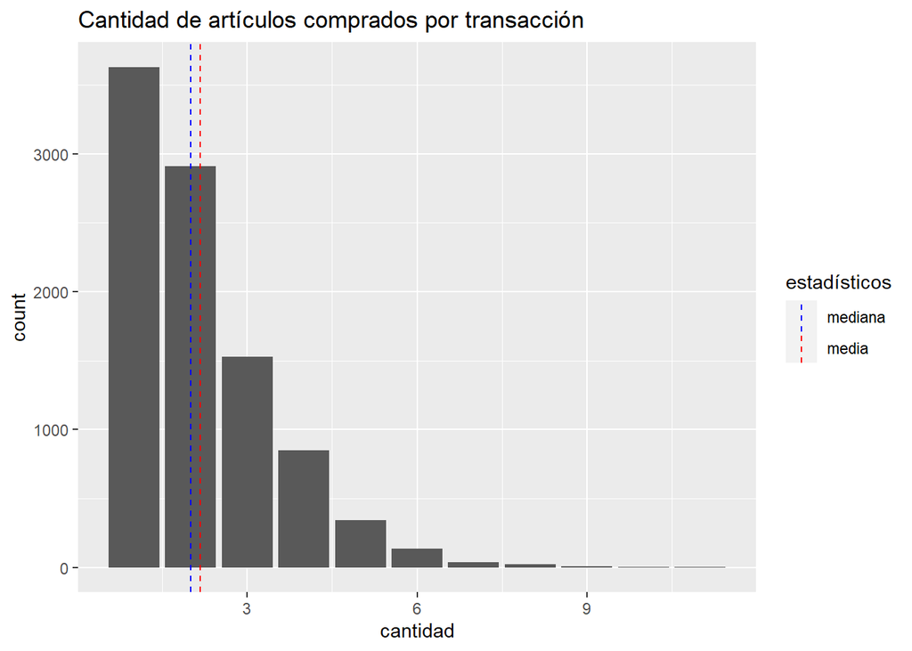

```r
# Gráficos
# Art. comprados por transacción
basket %>%
  group_by(Transaction) %>%
  summarise(cantidad = length(Item)) %>%
  ungroup() %>%
  ggplot(aes(x = cantidad)) +
  geom_bar() +
  geom_vline(aes(xintercept = mean(cantidad), color = "media"), linetype = "dashed") +
  geom_vline(aes(xintercept = median(cantidad), color = "mediana"), linetype = "dashed") +
  scale_color_manual(name = "estadísticos", values = c(mediana = "blue", media = "red")) +
  labs(title = "Cantidad de artículos comprados por transacción")
```

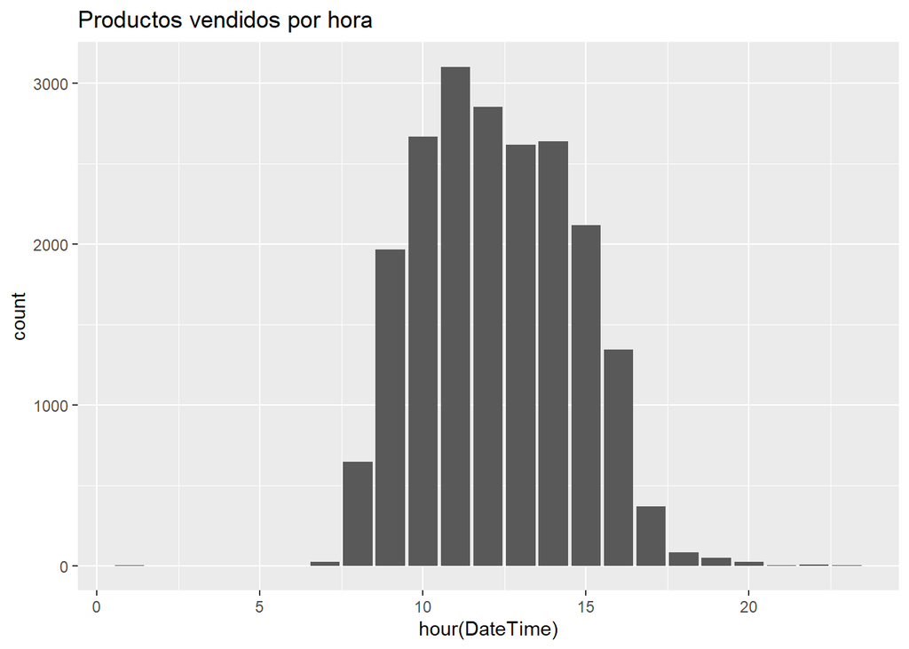

```r
# Productos vendidos según hora del día
ggplot(basket, aes(x = hour(DateTime))) +
  geom_bar() +
  labs(title = "Productos vendidos por hora")
```

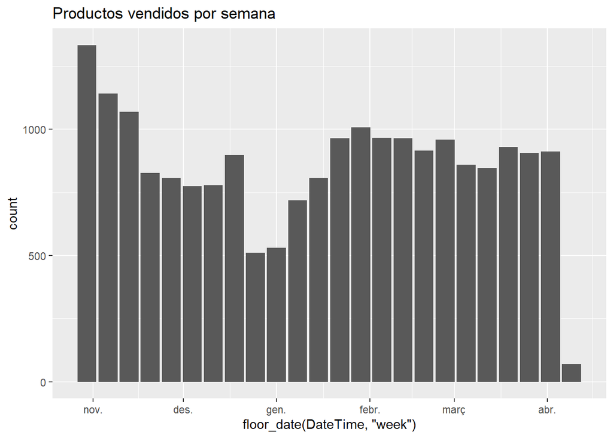

```r
# Evolución productos vendidos según semana
ggplot(basket, aes(x = floor_date(DateTime, "week"))) +
  geom_bar() +
  labs(title = "Productos vendidos por semana")
```

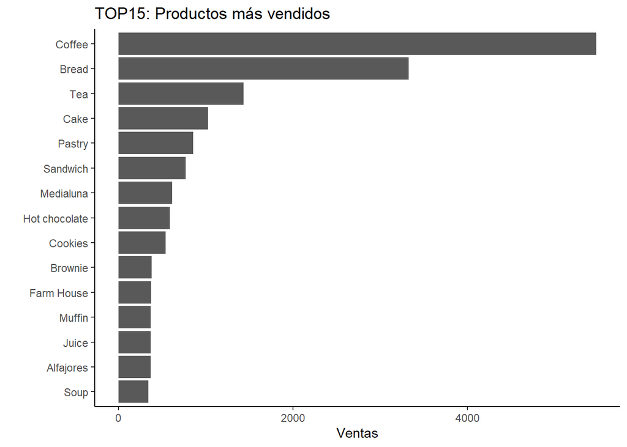

```r
# TOP 15 productos más vendidos
basket %>%
  group_by(Item) %>%
  summarise(Num_ventas =  n()) %>%
  arrange(desc(Num_ventas)) %>%
  slice(1:15) %>%
  ggplot(aes(x = reorder(Item, Num_ventas), y = Num_ventas)) +
  geom_bar(stat = "identity") +
  coord_flip() +
  labs(title = "TOP15: Productos más vendidos",
       x = "",
       y = "Ventas") +
  theme_classic()
```

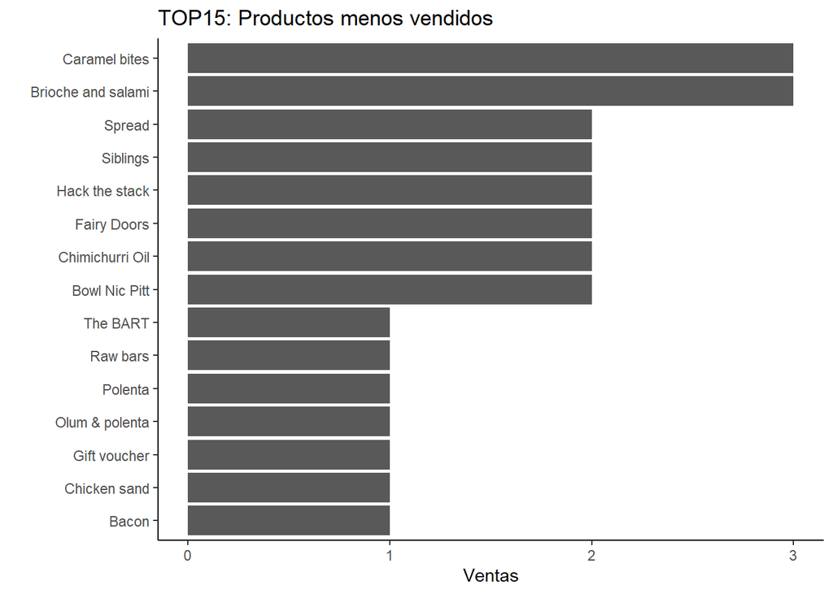

```r
basket %>%
  group_by(Item) %>%
  summarise(Num_ventas =  n()) %>%
  arrange(Num_ventas) %>%
  slice(1:15) %>%
  ggplot(aes(x = reorder(Item, Num_ventas), y = Num_ventas)) +
  geom_bar(stat = "identity") +
  coord_flip() +
  labs(title = "TOP15: Productos menos vendidos",
       x = "",
       y = "Ventas") +
  theme_classic()
```

## Market basket analysis

El análisis de la cesta de la compra se centra en encontrar asociaciones entre combinaciones de valores en un conjunto de datos, ello mediante algoritmos no supervisados como el de *apriori*. En este sentido, uno de los puntos más relevantes del uso de este método es la capacidad de establecer relaciones simplemente tomando, en este caso, los patrones de compra agregados de los clientes, sin necesidad de datos personales del cliente, como sí sucede en los análisis de clasificación o segmentación.

En esencia, el algoritmo *apriori* es un método de minería de datos que intenta identificar patrones en los datos con tal de crear un conjunto de reglas tal que, dado un conjunto de elementos, intenta identificar aquellos ítems que tienden a aparecer cuando observamos otro ítem, o un conjunto de estos. Por ejemplo:

$$\lbrace zapatos, calcetines \rbrace \to
\lbrace pantalones \rbrace$$

Así, en este caso hipotético, cuando observemos que el cliente añade zapatos y calcetines a su cesta, es posible que también pueda estar interesado en unos pantalones, dado que existe una asociación entre estos artículos. Conociendo esta información resulta posible generar recomendaciones personalizadas al adquirir productos, diseñar ofertas para la adquisición conjunta de productos o en general todo tipo de acciones orientadas a incrementar el cross-selling.

Este análisis de asociaciones es la base que se encuentra detrás de muchos de los algoritmos de recomendación usados en comercios electrónicos o marketplaces como el de Amazon. Tomando ese último caso, Amazon ofrece análisis de la cesta de la compra a comercios y partners que venden a través de su plataforma con tal de “verificar aquellos productos que más habitualmente se compran conjuntamente junto a los productos de la marca, ello con tal de identificar oportunidades de marketing cruzado y de agrupación” [(Amazon seller central)](https://sellercentral.amazon.com/gp/help/external/QRPYRECLEPVTRAN)

### Generación de reglas

Con tal de poder aplicar el algoritmo primero es necesario modificar el dataset con tal que se ajuste a un formato transaccional. Por ello se ha realizado una transposición de las transacciones, con tal que cada fila (observación) recoja en sus diferentes columnas los artículos adquiridos en cada transacción única. De esta manera obtenemos un juego de datos con 9464 filas, tantas como transacciones, y 11 columnas, tantas como el máximo de artículos adquiridos en una sola transacción, donde cada columna incluye un ítem de los comprados por el cliente.

Tras reimportar este conjunto de datos bajo el formato transaccional, llega la hora de decidir los parámetros que deberán cumplir las asociaciones identificadas por el algoritmo *a priori*. En esencia, al aplicar este algoritmo hay que prestar atención a las siguientes métricas:

- **Soporte**: métrica que mide el porcentaje de transacciones que aglutinan todos los ítems listados en la regla generada, ello sobre todo el conjunto de transacciones.
- **Confianza**: medida que indica la capacidad predictiva de la regla. Esto es, la probabilidad que habiéndose comprado ‘A’ también se compre ‘B’. Así cuando observemos un valor bajo será debido a que existe poca relación entre ambos ítem, en cambio un valor de 1 o cercano a 1 nos indicará que siempre, o casi siempre, que se observa un ítem, o un conjunto de estos, también observamos la adquisición del otro.
- **Elevación**: métrica que indica en qué proporción se observa la combinación de ambos ítem, o conjunto de estos, respecto a que estos se observen por separado. Así un valor de elevación elevado, superior a 1, nos indicará que la combinación de ambos ítems se da más habitualmente de lo esperado y, por ende, es altamente probable que cuando se observe el primero también observemos el segundo ítem, pues existe efectivamente una relación entre adquirir y otro ítem, o conjunto de estos. En cambio, un valor inferior a 1 nos indicaría la relación opuesta. La métrica de elevación es producto de calcular una ratio entre el valor de soporte de la combinación de ambos ítem entre el valor de soporte de que se den por separado.

```r
library(arules)
library(arulesViz)

# Transponemos, de tal manera que los items de cada transacción queden recogidos en la misma fila
basket %>%
  group_by(Transaction) %>%
  mutate(c_name = row_number()) %>%
  select(-DateTime) %>%
  pivot_wider(names_from = c_name, values_from = Item, names_prefix = "Item_") %>%
  ungroup() %>%
  select(-Transaction) -> data

# Guardamos el nuevo fichero y lo reimportamos en formato transaccional
write.csv(data, file = "Data/items.csv", row.names = FALSE)
data_items <- read.transactions(file = "Data/items.csv", format = "basket", sep = ",", header = TRUE)

# Parece que se ha importado bien: seguimos teniendo 93 items diferentes y 9465 transacciones.
summary(data_items)
```

```
## transactions as itemMatrix in sparse format with
##  9464 rows (elements/itemsets/transactions) and
##  93 columns (items) and a density of 0.02145766
##
## most frequent items:
##  Coffee   Bread     Tea    Cake  Pastry (Other)
##    4528    3097    1350     983     815    8113
##
## element (itemset/transaction) length distribution:
## sizes
##    1    2    3    4    5    6    7    8    9   10
## 3947 3059 1471  662  234   64   17    4    5    1
##
##    Min. 1st Qu.  Median    Mean 3rd Qu.    Max.
##   1.000   1.000   2.000   1.996   3.000  10.000
##
## includes extended item information - examples:
##                     labels
## 1 Afternoon with the baker
## 2                Alfajores
## 3          Argentina Night
```

```r
summary(itemFrequency(data_items))
```

```
##      Min.   1st Qu.    Median      Mean   3rd Qu.      Max.
## 0.0001057 0.0006340 0.0016906 0.0214577 0.0150042 0.4784446
```

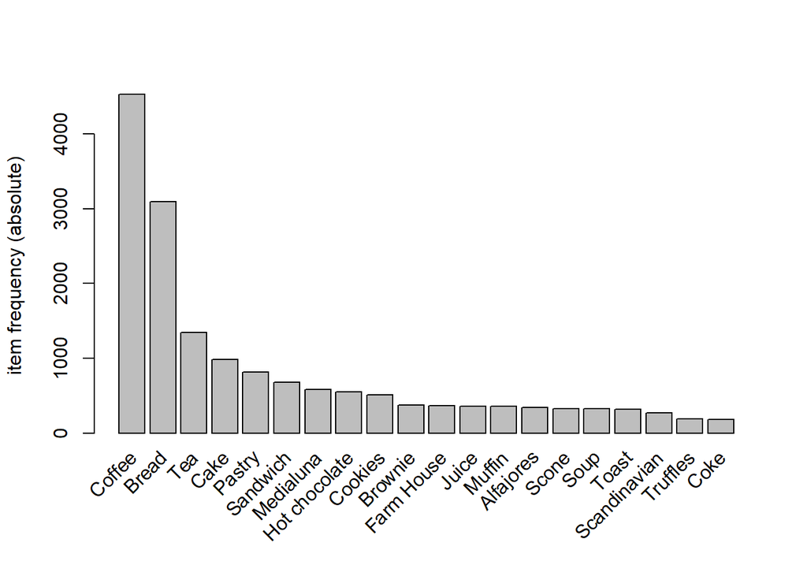

```r
itemFrequencyPlot(data_items,topN = 20, type = "absolute")
```

#### **Prueba 1: parámetros bajos**

La lógica seguida con tal de encontrar unos umbrales óptimos de soporte y confianza ha sido la propia de un proceso de prueba y error. En este sentido primero se han establecido unos parámetros muy bajos que permitieran crear un conjunto de reglas grande. Con ello sea ha obtenido un conjunto de algo más de 1000 reglas y se ha obtenido un `summary` con tal de visualizar los valores medios de los parámetros, tomándose de referencia la media de estos para definir unos umbrales más restrictivos en las siguientes prueba.

```r
# Reglas, prueba 1: parámetros muy bajos
rules_low = apriori(data_items, parameter = list(support = 0.001, confidence = 0, minlen = 2))
```

```
## Apriori
##
## Parameter specification:
##  confidence minval smax arem  aval originalSupport maxtime support minlen
##           0    0.1    1 none FALSE            TRUE       5   0.001      2
##  maxlen target  ext
##      10  rules TRUE
##
## Algorithmic control:
##  filter tree heap memopt load sort verbose
##     0.1 TRUE TRUE  FALSE TRUE    2    TRUE
##
## Absolute minimum support count: 9
##
## set item appearances ...[0 item(s)] done [0.00s].
## set transactions ...[93 item(s), 9464 transaction(s)] done [0.00s].
## sorting and recoding items ... [57 item(s)] done [0.00s].
## creating transaction tree ... done [0.00s].
## checking subsets of size 1 2 3 4 done [0.00s].
## writing ... [1003 rule(s)] done [0.00s].
## creating S4 object  ... done [0.00s].
```

```r
summary(rules_low)
```

```
## set of 1003 rules
##
## rule length distribution (lhs + rhs):sizes
##   2   3   4
## 486 501  16
##
##    Min. 1st Qu.  Median    Mean 3rd Qu.    Max.
##   2.000   2.000   3.000   2.531   3.000   4.000
##
## summary of quality measures:
##     support           confidence          coverage             lift
##  Min.   :0.001057   Min.   :0.003229   Min.   :0.001268   Min.   : 0.1878
##  1st Qu.:0.001374   1st Qu.:0.045852   1st Qu.:0.009140   1st Qu.: 0.8382
##  Median :0.001902   Median :0.094340   Median :0.028106   Median : 1.1929
##  Mean   :0.003927   Mean   :0.171668   Mean   :0.062005   Mean   : 1.6539
##  3rd Qu.:0.003593   3rd Qu.:0.229029   3rd Qu.:0.054734   3rd Qu.: 1.7133
##  Max.   :0.090025   Max.   :0.875000   Max.   :0.478445   Max.   :56.2377
##      count
##  Min.   : 10.00
##  1st Qu.: 13.00
##  Median : 18.00
##  Mean   : 37.16
##  3rd Qu.: 34.00
##  Max.   :852.00
##
## mining info:
##        data ntransactions support confidence
##  data_items          9464   0.001          0
##                                                                                       call
##  apriori(data = data_items, parameter = list(support = 0.001, confidence = 0, minlen = 2))
```

#### **Prueba 2: parámetros medios**

En una segunda prueba, se han establecido unos umbrales “medios”, con un valor de 0.003 para el parámetro de soporte mínimo, esto es, que se trate de conjuntos de itemsets que se den en el 0,3% de las transacciones. A la práctica, dado que tenemos cerca de 9500 transacciones, supone que para considerar cualquier asociación esta debe repetirse un mínimo de 28 veces. Así mismo se ha establecido una confianza mínima del 0.2, esto es, del 20%. Con lo cual solo se considerarán reglas que se cumplan como mínimo el 20% de las ocasiones. Como se puede ver en el `summary` generado en la prueba 1, estos umbrales van en la línea de los valores medios obtenidos por el conjunto de reglas generados en la primera prueba.

```r
# Reglas, prueba 2: parámetros medios
rules_mid = apriori(data_items, parameter = list(support = 0.003, confidence = 0.2, minlen = 2))
inspect_mid <- inspect(sort(rules_mid, by = "lift"), ruleSep = "--->", itemSep = " + ", setStart = "", setEnd ="", linebreak = FALSE, verbose = FALSE)
```

```r
summary(rules_mid)
```

```
## set of 100 rules
##
## rule length distribution (lhs + rhs):sizes
##  2  3
## 63 37
##
##    Min. 1st Qu.  Median    Mean 3rd Qu.    Max.
##    2.00    2.00    2.00    2.37    3.00    3.00
##
## summary of quality measures:
##     support           confidence        coverage             lift
##  Min.   :0.003064   Min.   :0.2000   Min.   :0.004015   Min.   :0.4563
##  1st Qu.:0.003883   1st Qu.:0.2531   1st Qu.:0.010223   1st Qu.:0.8025
##  Median :0.005653   Median :0.3967   Median :0.016959   Median :1.0322
##  Mean   :0.010871   Mean   :0.4048   Mean   :0.030507   Mean   :1.1306
##  3rd Qu.:0.010963   3rd Qu.:0.5312   3rd Qu.:0.035001   3rd Qu.:1.2616
##  Max.   :0.090025   Max.   :0.8158   Max.   :0.327240   Max.   :3.7063
##      count
##  Min.   : 29.00
##  1st Qu.: 36.75
##  Median : 53.50
##  Mean   :102.88
##  3rd Qu.:103.75
##  Max.   :852.00
##
## mining info:
##        data ntransactions support confidence
##  data_items          9464   0.003        0.2
##                                                                                         call
##  apriori(data = data_items, parameter = list(support = 0.003, confidence = 0.2, minlen = 2))
```

```r
knitr::kable(inspect_mid)
```

|  | lhs |  | rhs | support | confidence | coverage | lift | count |
| --- | --- | --- | --- | --- | --- | --- | --- | --- |
| [1] | Coke | —> | Sandwich | 0.0051775 | 0.2663043 | 0.0194421 | 3.7063299 | 49 |
| [2] | Mineral water | —> | Sandwich | 0.0032756 | 0.2313433 | 0.0141589 | 3.2197542 | 31 |
| [3] | Coffee + Soup | —> | Sandwich | 0.0035926 | 0.2266667 | 0.0158495 | 3.1546667 | 34 |
| [4] | Coffee + Hot chocolate | —> | Cake | 0.0068681 | 0.2321429 | 0.0295858 | 2.2349949 | 65 |
| [5] | Jammie Dodgers | —> | Cake | 0.0030642 | 0.2320000 | 0.0132079 | 2.2336195 | 29 |
| [6] | Coffee + Tea | —> | Cake | 0.0100380 | 0.2012712 | 0.0498732 | 1.9377726 | 95 |
| [7] | Soup | —> | Tea | 0.0090871 | 0.2638037 | 0.0344463 | 1.8493615 | 86 |
| [8] | Spanish Brunch | —> | Tea | 0.0046492 | 0.2558140 | 0.0181741 | 1.7933506 | 44 |
| [9] | Chicken Stew | —> | Tea | 0.0031699 | 0.2439024 | 0.0129966 | 1.7098464 | 30 |
| [10] | Extra Salami or Feta | —> | Coffee | 0.0032756 | 0.8157895 | 0.0040152 | 1.7050865 | 31 |
| [11] | Scone | —> | Tea | 0.0083474 | 0.2415902 | 0.0345520 | 1.6936369 | 79 |
| [12] | Keeping It Local | —> | Coffee | 0.0053888 | 0.8095238 | 0.0066568 | 1.6919906 | 51 |
| [13] | Cake | —> | Tea | 0.0237743 | 0.2288911 | 0.1038673 | 1.6046117 | 225 |
| [14] | Tiffin | —> | Tea | 0.0034869 | 0.2260274 | 0.0154269 | 1.5845358 | 33 |
| [15] | Toast | —> | Coffee | 0.0236686 | 0.7044025 | 0.0336010 | 1.4722759 | 224 |
| [16] | Bread + Cake | —> | Tea | 0.0048605 | 0.2081448 | 0.0233516 | 1.4591721 | 46 |
| [17] | Cake + Sandwich | —> | Coffee | 0.0046492 | 0.6769231 | 0.0068681 | 1.4148410 | 44 |
| [18] | Sandwich | —> | Tea | 0.0143702 | 0.2000000 | 0.0718512 | 1.4020741 | 136 |
| [19] | Hot chocolate + Pastry | —> | Coffee | 0.0038039 | 0.6666667 | 0.0057058 | 1.3934040 | 36 |
| [20] | Sandwich + Soup | —> | Coffee | 0.0035926 | 0.6538462 | 0.0054945 | 1.3666078 | 34 |
| [21] | Hot chocolate + Medialuna | —> | Coffee | 0.0030642 | 0.6444444 | 0.0047549 | 1.3469572 | 29 |
| [22] | Tartine | —> | Coffee | 0.0030642 | 0.6304348 | 0.0048605 | 1.3176755 | 29 |
| [23] | Salad | —> | Coffee | 0.0065511 | 0.6262626 | 0.0104607 | 1.3089553 | 62 |
| [24] | Cookies + Hot chocolate | —> | Coffee | 0.0036982 | 0.6140351 | 0.0060228 | 1.2833984 | 35 |
| [25] | Bakewell | —> | Coffee | 0.0030642 | 0.6041667 | 0.0050719 | 1.2627724 | 29 |
| [26] | Cookies + Juice | —> | Coffee | 0.0036982 | 0.6034483 | 0.0061285 | 1.2612709 | 35 |
| [27] | Cake + Hot chocolate | —> | Coffee | 0.0068681 | 0.6018519 | 0.0114117 | 1.2579342 | 65 |
| [28] | Spanish Brunch | —> | Coffee | 0.0108833 | 0.5988372 | 0.0181741 | 1.2516332 | 103 |
| [29] | Cake + Cookies | —> | Coffee | 0.0042265 | 0.5797101 | 0.0072908 | 1.2116557 | 40 |
| [30] | Vegan mincepie | —> | Coffee | 0.0031699 | 0.5769231 | 0.0054945 | 1.2058304 | 30 |

[output cut: 70 more lines]

#### **Prueba 3: parámetros altos**

Seguidamente, y repitiendo de nuevo el proceso anterior, se genera un nuevo conjunto de reglas, esta vez con umbrales “elevados” dadas las características del conjunto de transacciones: soporte del 0,5% y confianza del 40%.

Aplicado el algoritmo obtenemos un conjunto de reglas mucho más reducido, con 25 asociaciones, con un soporte medio del 1,8% y una confianza media del 53%.

```r
# Reglas, prueba 3, parámetros altos:
rules_high = apriori(data_items, parameter = list(support = 0.005, confidence = 0.4, minlen = 2))
inspect_high <- inspect(sort(rules_high, by = "lift"), ruleSep = "--->", itemSep = " + ", setStart = "", setEnd ="", linebreak = FALSE)
```

```r
summary(rules_high)
```

```
## set of 25 rules
##
## rule length distribution (lhs + rhs):sizes
##  2  3
## 19  6
##
##    Min. 1st Qu.  Median    Mean 3rd Qu.    Max.
##    2.00    2.00    2.00    2.24    2.00    3.00
##
## summary of quality measures:
##     support           confidence        coverage             lift
##  Min.   :0.005389   Min.   :0.4000   Min.   :0.006657   Min.   :0.836
##  1st Qu.:0.006868   1st Qu.:0.4890   1st Qu.:0.015427   1st Qu.:1.022
##  Median :0.015850   Median :0.5270   Median :0.033601   Median :1.101
##  Mean   :0.018419   Mean   :0.5323   Mean   :0.034911   Mean   :1.113
##  3rd Qu.:0.023669   3rd Qu.:0.5521   3rd Qu.:0.040046   3rd Qu.:1.154
##  Max.   :0.054734   Max.   :0.8095   Max.   :0.103867   Max.   :1.692
##      count
##  Min.   : 51.0
##  1st Qu.: 65.0
##  Median :150.0
##  Mean   :174.3
##  3rd Qu.:224.0
##  Max.   :518.0
##
## mining info:
##        data ntransactions support confidence
##  data_items          9464   0.005        0.4
##                                                                                         call
##  apriori(data = data_items, parameter = list(support = 0.005, confidence = 0.4, minlen = 2))
```

```r
knitr::kable(inspect_high)
```

|  | lhs |  | rhs | support | confidence | coverage | lift | count |
| --- | --- | --- | --- | --- | --- | --- | --- | --- |
| [1] | Keeping It Local | —> | Coffee | 0.0053888 | 0.8095238 | 0.0066568 | 1.6919906 | 51 |
| [2] | Toast | —> | Coffee | 0.0236686 | 0.7044025 | 0.0336010 | 1.4722759 | 224 |
| [3] | Salad | —> | Coffee | 0.0065511 | 0.6262626 | 0.0104607 | 1.3089553 | 62 |
| [4] | Cake + Hot chocolate | —> | Coffee | 0.0068681 | 0.6018519 | 0.0114117 | 1.2579342 | 65 |
| [5] | Spanish Brunch | —> | Coffee | 0.0108833 | 0.5988372 | 0.0181741 | 1.2516332 | 103 |
| [6] | Medialuna | —> | Coffee | 0.0351860 | 0.5692308 | 0.0618132 | 1.1897527 | 333 |
| [7] | Pastry | —> | Coffee | 0.0475486 | 0.5521472 | 0.0861158 | 1.1540463 | 450 |
| [8] | Tiffin | —> | Coffee | 0.0084531 | 0.5479452 | 0.0154269 | 1.1452636 | 80 |
| [9] | Alfajores | —> | Coffee | 0.0196534 | 0.5406977 | 0.0363483 | 1.1301155 | 186 |
| [10] | Hearty & Seasonal | —> | Coffee | 0.0057058 | 0.5400000 | 0.0105664 | 1.1286572 | 54 |
| [11] | Juice | —> | Coffee | 0.0206044 | 0.5342466 | 0.0385672 | 1.1166320 | 195 |
| [12] | Sandwich | —> | Coffee | 0.0382502 | 0.5323529 | 0.0718512 | 1.1126741 | 362 |
| [13] | Cake | —> | Coffee | 0.0547337 | 0.5269583 | 0.1038673 | 1.1013987 | 518 |
| [14] | Scone | —> | Coffee | 0.0180685 | 0.5229358 | 0.0345520 | 1.0929912 | 171 |
| [15] | Cookies | —> | Coffee | 0.0282122 | 0.5184466 | 0.0544167 | 1.0836084 | 267 |
| [16] | Hot chocolate | —> | Coffee | 0.0295858 | 0.5072464 | 0.0583263 | 1.0601987 | 280 |
| [17] | Jammie Dodgers | —> | Coffee | 0.0066568 | 0.5040000 | 0.0132079 | 1.0534134 | 63 |
| [18] | Brownie | —> | Coffee | 0.0196534 | 0.4907652 | 0.0400465 | 1.0257512 | 186 |
| [19] | Muffin | —> | Coffee | 0.0188081 | 0.4890110 | 0.0384615 | 1.0220848 | 178 |
| [20] | Soup | —> | Coffee | 0.0158495 | 0.4601227 | 0.0344463 | 0.9617052 | 150 |
| [21] | Bread + Hot chocolate | —> | Coffee | 0.0061285 | 0.4566929 | 0.0134193 | 0.9545366 | 58 |
| [22] | Bread + Cake | —> | Coffee | 0.0100380 | 0.4298643 | 0.0233516 | 0.8984619 | 95 |
| [23] | Bread + Sandwich | —> | Coffee | 0.0071851 | 0.4223602 | 0.0170118 | 0.8827777 | 68 |
| [24] | Cake + Tea | —> | Coffee | 0.0100380 | 0.4222222 | 0.0237743 | 0.8824892 | 95 |
| [25] | Bread + Medialuna | —> | Coffee | 0.0067625 | 0.4000000 | 0.0169062 | 0.8360424 | 64 |

#### **Prueba 4: parámetros medios, filtrando por elevación y confianza**

Finalmente, dado que el conjunto de reglas anterior, generado con umbrales elevados para los parámetros de soporte y confianza, da como resultado un conjunto de reglas probablemente demasiado restrictivo, se ha optado por un punto intermedio como solución final.

En este sentido, el conjunto de reglas final, a partir del cual se extraerán las conclusiones, se ha construido usando umbrales medios (soporte del 0,3% y confianza del 20%), si bien filtrando las reglas generadas en base al valor de elevación. Así, solo se han considerado las reglas donde el valor de elevación sea superior a 1. Consecuentemente, únicamente se han conservado aquellas reglas donde efectivamente parece haber una relación al adquirir un conjunto de productos.

Con todo, de aquellas que cumplan los requisitos descritos, se han seleccionado las 50 con mayores valores de confianza. Estas 50 reglas cuentan con un soporte medio del 1,1%, una confianza media del 48% y un valor de elevación medio de 1.44. Así mismo, todas las asociaciones corresponden a sets de entre 2 y 3 ítems.

```r
# Reglas, prueba 4, parámetros medio-altos:
rules_final <- apriori(data_items, parameter = list(support = 0.003, confidence = 0.2, minlen = 2))
rules_final <- sort(subset(rules_final, lift > 1), by = c("confidence", "lift"))

inspect_final <- inspect(rules_final[1:50], ruleSep = "--->", itemSep = " + ", setStart = "", setEnd ="", linebreak = FALSE)
```

```r
summary(rules_final)
```

```
## set of 54 rules
##
## rule length distribution (lhs + rhs):sizes
##  2  3
## 38 16
##
##    Min. 1st Qu.  Median    Mean 3rd Qu.    Max.
##   2.000   2.000   2.000   2.296   3.000   3.000
##
## summary of quality measures:
##     support           confidence        coverage             lift
##  Min.   :0.003064   Min.   :0.2000   Min.   :0.004015   Min.   :1.011
##  1st Qu.:0.003698   1st Qu.:0.2842   1st Qu.:0.007132   1st Qu.:1.106
##  Median :0.005125   Median :0.5278   Median :0.014582   Median :1.255
##  Mean   :0.011388   Mean   :0.4760   Mean   :0.026516   Mean   :1.435
##  3rd Qu.:0.017144   3rd Qu.:0.5941   3rd Qu.:0.035899   3rd Qu.:1.556
##  Max.   :0.054734   Max.   :0.8158   Max.   :0.103867   Max.   :3.706
##      count
##  Min.   : 29.0
##  1st Qu.: 35.0
##  Median : 48.5
##  Mean   :107.8
##  3rd Qu.:162.2
##  Max.   :518.0
##
## mining info:
##        data ntransactions support confidence
##  data_items          9464   0.003        0.2
##                                                                                         call
##  apriori(data = data_items, parameter = list(support = 0.003, confidence = 0.2, minlen = 2))
```

```r
knitr::kable(inspect_final)
```

|  | lhs |  | rhs | support | confidence | coverage | lift | count |
| --- | --- | --- | --- | --- | --- | --- | --- | --- |
| [1] | Extra Salami or Feta | —> | Coffee | 0.0032756 | 0.8157895 | 0.0040152 | 1.705086 | 31 |
| [2] | Keeping It Local | —> | Coffee | 0.0053888 | 0.8095238 | 0.0066568 | 1.691991 | 51 |
| [3] | Toast | —> | Coffee | 0.0236686 | 0.7044025 | 0.0336010 | 1.472276 | 224 |
| [4] | Cake + Sandwich | —> | Coffee | 0.0046492 | 0.6769231 | 0.0068681 | 1.414841 | 44 |
| [5] | Hot chocolate + Pastry | —> | Coffee | 0.0038039 | 0.6666667 | 0.0057058 | 1.393404 | 36 |
| [6] | Sandwich + Soup | —> | Coffee | 0.0035926 | 0.6538462 | 0.0054945 | 1.366608 | 34 |
| [7] | Hot chocolate + Medialuna | —> | Coffee | 0.0030642 | 0.6444444 | 0.0047549 | 1.346957 | 29 |
| [8] | Tartine | —> | Coffee | 0.0030642 | 0.6304348 | 0.0048605 | 1.317675 | 29 |
| [9] | Salad | —> | Coffee | 0.0065511 | 0.6262626 | 0.0104607 | 1.308955 | 62 |
| [10] | Cookies + Hot chocolate | —> | Coffee | 0.0036982 | 0.6140351 | 0.0060228 | 1.283398 | 35 |
| [11] | Bakewell | —> | Coffee | 0.0030642 | 0.6041667 | 0.0050719 | 1.262772 | 29 |
| [12] | Cookies + Juice | —> | Coffee | 0.0036982 | 0.6034483 | 0.0061285 | 1.261271 | 35 |
| [13] | Cake + Hot chocolate | —> | Coffee | 0.0068681 | 0.6018519 | 0.0114117 | 1.257934 | 65 |
| [14] | Spanish Brunch | —> | Coffee | 0.0108833 | 0.5988372 | 0.0181741 | 1.251633 | 103 |
| [15] | Cake + Cookies | —> | Coffee | 0.0042265 | 0.5797101 | 0.0072908 | 1.211656 | 40 |
| [16] | Vegan mincepie | —> | Coffee | 0.0031699 | 0.5769231 | 0.0054945 | 1.205830 | 30 |
| [17] | Medialuna | —> | Coffee | 0.0351860 | 0.5692308 | 0.0618132 | 1.189753 | 333 |
| [18] | Cake + Juice | —> | Coffee | 0.0039096 | 0.5522388 | 0.0070795 | 1.154238 | 37 |
| [19] | Pastry | —> | Coffee | 0.0475486 | 0.5521472 | 0.0861158 | 1.154046 | 450 |
| [20] | Tiffin | —> | Coffee | 0.0084531 | 0.5479452 | 0.0154269 | 1.145264 | 80 |
| [21] | Alfajores | —> | Coffee | 0.0196534 | 0.5406977 | 0.0363483 | 1.130116 | 186 |
| [22] | Hearty & Seasonal | —> | Coffee | 0.0057058 | 0.5400000 | 0.0105664 | 1.128657 | 54 |
| [23] | The Nomad | —> | Coffee | 0.0032756 | 0.5344828 | 0.0061285 | 1.117126 | 31 |
| [24] | Juice | —> | Coffee | 0.0206044 | 0.5342466 | 0.0385672 | 1.116632 | 195 |
| [25] | Sandwich | —> | Coffee | 0.0382502 | 0.5323529 | 0.0718512 | 1.112674 | 362 |
| [26] | Frittata | —> | Coffee | 0.0045435 | 0.5308642 | 0.0085587 | 1.109562 | 43 |
| [27] | Medialuna + Pastry | —> | Coffee | 0.0048605 | 0.5287356 | 0.0091927 | 1.105114 | 46 |
| [28] | Cake | —> | Coffee | 0.0547337 | 0.5269583 | 0.1038673 | 1.101399 | 518 |
| [29] | Scone | —> | Coffee | 0.0180685 | 0.5229358 | 0.0345520 | 1.092991 | 171 |
| [30] | Cookies | —> | Coffee | 0.0282122 | 0.5184466 | 0.0544167 | 1.083608 | 267 |
| [31] | Tea + Toast | —> | Coffee | 0.0032756 | 0.5081967 | 0.0064455 | 1.062185 | 31 |
| [32] | Hot chocolate | —> | Coffee | 0.0295858 | 0.5072464 | 0.0583263 | 1.060199 | 280 |
| [33] | Jammie Dodgers | —> | Coffee | 0.0066568 | 0.5040000 | 0.0132079 | 1.053413 | 63 |
| [34] | Smoothies | —> | Coffee | 0.0040152 | 0.4935065 | 0.0081361 | 1.031481 | 38 |
| [35] | Brownie | —> | Coffee | 0.0196534 | 0.4907652 | 0.0400465 | 1.025751 | 186 |
| [36] | Muffin | —> | Coffee | 0.0188081 | 0.4890110 | 0.0384615 | 1.022085 | 178 |
| [37] | Pastry + Tea | —> | Coffee | 0.0046492 | 0.4835165 | 0.0096154 | 1.010601 | 44 |
| [38] | Jammie Dodgers | —> | Bread | 0.0046492 | 0.3520000 | 0.0132079 | 1.075663 | 44 |
| [39] | Pastry | —> | Bread | 0.0291631 | 0.3386503 | 0.0861158 | 1.034868 | 276 |
| [40] | Jam | —> | Bread | 0.0050719 | 0.3380282 | 0.0150042 | 1.032967 | 48 |
| [41] | Coke | —> | Sandwich | 0.0051775 | 0.2663043 | 0.0194421 | 3.706330 | 49 |
| [42] | Soup | —> | Tea | 0.0090871 | 0.2638037 | 0.0344463 | 1.849362 | 86 |
| [43] | Spanish Brunch | —> | Tea | 0.0046492 | 0.2558140 | 0.0181741 | 1.793351 | 44 |
| [44] | Chicken Stew | —> | Tea | 0.0031699 | 0.2439024 | 0.0129966 | 1.709846 | 30 |
| [45] | Scone | —> | Tea | 0.0083474 | 0.2415902 | 0.0345520 | 1.693637 | 79 |
| [46] | Coffee + Hot chocolate | —> | Cake | 0.0068681 | 0.2321429 | 0.0295858 | 2.234995 | 65 |
| [47] | Jammie Dodgers | —> | Cake | 0.0030642 | 0.2320000 | 0.0132079 | 2.233620 | 29 |
| [48] | Mineral water | —> | Sandwich | 0.0032756 | 0.2313433 | 0.0141589 | 3.219754 | 31 |
| [49] | Cake | —> | Tea | 0.0237743 | 0.2288911 | 0.1038673 | 1.604612 | 225 |
| [50] | Coffee + Soup | —> | Sandwich | 0.0035926 | 0.2266667 | 0.0158495 | 3.154667 | 34 |

### Visualización de las reglas

Más allá de las asociaciones particulares entre ítems, se constata como cierta la hipótesis planteada antes de aplicar el algoritmo. Efectivamente, parece ser que la mayoría de asociaciones se dan entre una comida y una bebida. Dicho esto, al profundizar en las relaciones, observamos que el café se tiende a consumir más juntamente con productos dulces como la tarta ‘Bakewell’ o los ‘jammie dodgers’ y con productos de elaboración media-alta como la ‘frittata’ o los pasteles de carne picada (mincepie). Por su parte, el té parece combinarse más bien con productos también de elaboración media-alta aunque más orientados a ser consumidos como almuerzo (sopas, estofado de pollo..), mientras que el café parecía combinarse con productos más “ligeros” como las ensaladas u orientados a ser consumidos como desayuno ‘ligero’ o comida de entre horas, como los ‘tiffin’ o los ‘tartine’. Finalmente, los sándwiches parecen ir muy de la mano de los refrescos como la cola o el agua mineral.

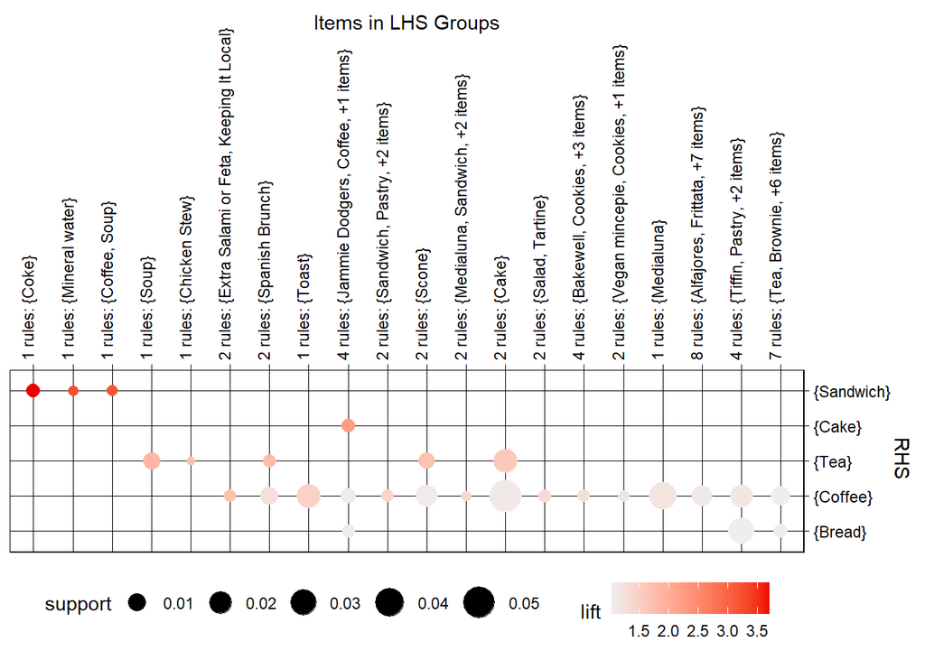

```r
plot(rules_final[1:50], method = "grouped")
```

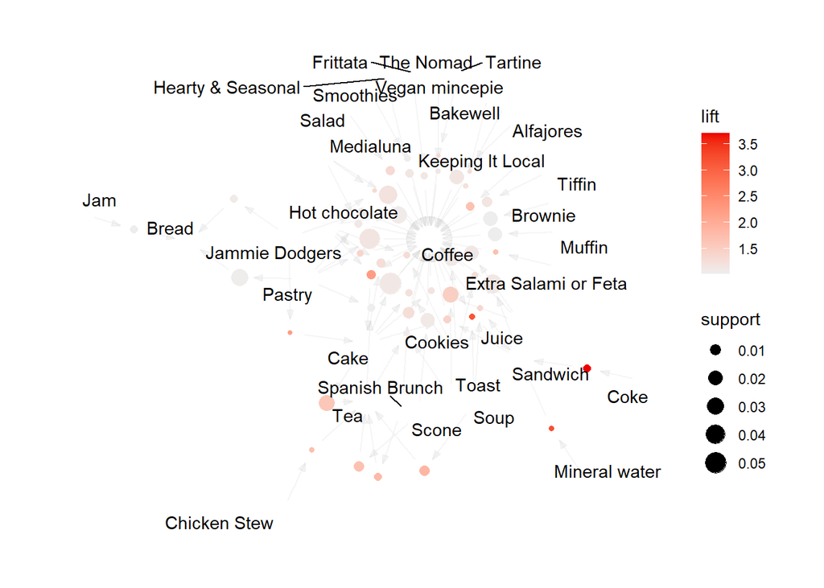

```r
plot(rules_final[1:50], method = "graph")
```

## Conclusiones

En la línea de lo expuesto anteriormente, el gerente de The Bread Basket debería tener en cuenta los siguientes aspectos sobre el negocio:

- El grueso de las transacciones se realizan en las horas centrales del día, aproximadamente entre media mañana hasta primera hora de la tarde. En este sentido, la oferta de productos debería estar centrada hacia el tipo de comidas y bebidas que se suelen ser consumidas en esta franja (brunch y almuerzo principalmente), en caso de que efectivamente se quisiera enfocar el negocio hacia este segmento.
- El café y el pan son claramente los dos productos estrellas de la tienda, aunque no hay una relación clara entre adquirir uno y otro producto, esto es, no tienden a complementarse y por ende las razones que llevan a adquirir uno u otro producto son diferentes. Si bien, especialmente en el caso del café, se tiende a adquirir como producto complementario junto con otros productos
- Existen varios productos que apenas aparecen en las transacciones. En cuanto a comidas respecta, si se compara con los artículos más comprados, todo parece indicar que los productos que mejor funcionan tienden a ser aquellos que requieren de una cierta elaboración, mientras que los de menor elaboración tienden a tener menor demanda. Así pues, podría considerarse adaptar la oferta y aunar esfuerzos en los productos de elaboración más compleja, que son los que suelen funcionar mejor en cuanto a ventas.
- Respecto a los productos que se acostumbran a adquirir conjuntamente, existe un patrón claro: habitualmente se combinan las comidas con las bebidas. Así pues, fuera bueno que cuando el cliente adquiriera una comida se le sugiriera también la adquisición de una bebida. En este sentido, todo parece indicar que generalmente el mejor complemento es el café, dado que es el producto que aparece en el grueso de las asociaciones generadas, si bien parece ser especialmente recomendable cuando se adquieran dulces o productos habitualmente consumidos entre horas o como almuerzo “ligero”. Por otro lado, el té se posiciona como un buen complemento cuando se adquieren productos más propios de un almuerzo más convencional (sopas, estofados…), mientras que el agua mineral o los refrescos como la cola parecen un buen complemento cuando el cliente se decante por un sándwich.
- Dadas las asociaciones descritas en el punto anterior, también podría resultar interesante no solo sugerir, sino también crear ofertas con tal de incentivar la adquisición conjunta de estos productos, o bien situarlos estratégicamente. Por ejemplo, posicionar la cafetera de tal manera que esté al lado de los dulces y la pastelería.

### Limitaciones del algoritmo

Los análisis de asociaciones, y el algoritmo *apriori* en particular, parten como todos los métodos de ciertas limitaciones. A nivel técnico, debe tenerse en cuenta que aplicar este método a grandes conjuntos de datos, con cientos de miles o millones de transacciones y gran cantidad de ítems diferentes, puede llegar a ser especialmente costoso computacionalmente. Por un lado, dado que este algoritmo debe recalcular continuamente la métrica de soporte cada vez que genera una nueva regla, con tal de garantizar que supere el umbral establecido y, por otro, dado que en un primer momento las reglas se generan combinando todos los ítems unos con otros, sin primero comprobar que cualquiera de las combinaciones generadas en un inicio efectivamente existan en alguna transacción (esto es, que se cree un itemset que combine, por ejemplo, los ítems ‘sopa’ y ‘helado’ pese a que no haya transacción alguna que incluya ambos ítems a la vez). Ello, sumado a otras especificidades de este algoritmo, hace que sea un método muy intensivo en uso de memoria y potencialmente poco eficiente (Fournier-Viger et. al, pp. 4, 2017)

Más allá de las limitaciones técnicas, debe tenerse en cuenta que con este tipo de algoritmos resulta difícil generalizar los resultados del análisis, incluso cuando se trate de tiendas de la misma cadena, pues como expone Linoff (2011), existen multitud de factores que impactan en los patrones de compra de los clientes (situación geográfica, variables sociodemográficas, publicidad, etc.). Así mismo, es un método que produce resultados pobres cuando se aplica a sectores o negocios donde habitualmente ya se venden productos de forma agrupada, como en el sector financiero, dado que estas asociaciones (productos que habitualmente ya se ofrecen de forma conjunta) son los que terminarán dominando las asociaciones identificadas (Linoff, 2011).

Adicionalmente, este tipo de algoritmos solo pueden tratar con datos categóricos, así pues, antes de aplicar cualquier tipo de análisis de asociaciones resulta imperativo discrecionalizar cualquier atributo numérico. A ello podemos sumarle que, aunque extensible a muchos otros algoritmos, evaluar el sentido de los resultados, en este caso las asociaciones/reglas identificadas, queda completamente en manos del analista.

**Bibliografia:**

- Fournier-Viger, P., Lin, J.C.-W., Vo, B., Chi, T.T., Zhang, J. and Le, H.B. (2017). A survey of itemset mining. Wiley Interdisciplinary Reviews: Data Mining and Knowledge Discovery, 7(4), p.e1207. doi:10.1002/widm.1207.
- Linoff, Gordon. (2011). Data mining techniques for marketing, sales, and customer relationship management. Wiley.